# Reference video

## Customizable volcano plots

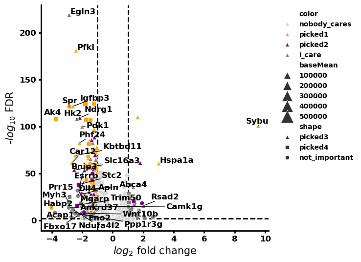

```python
# 设置图形大小
plt.figure(figsize = (6,6))

# 绘制散点图
ax = sns.scatterplot(data = df,
                    x = 'log2FoldChange',
                    y = 'nlog10',
                    hue = 'color', # 根据 'color' 列的值设置点的颜色
                    hue_order = ['nobody_cares', 'picked1', 'picked2', 'i_care'],  #定义颜色的顺序
                    palette = ['lightgrey', 'orange', 'purple', 'grey'], #为每种颜色指定相应的颜色值
                    style = 'shape',  #根据 'shape' 列的值设置点的形状
                    style_order = ['picked3', 'picked4', 'not_important'], #定义形状的顺序
                    markers = ['^', 's', 'o'],  #定义不同类别的标记形状
                    size = 'baseMean',
                    sizes = (40, 400))  #点大小的范围


# 添加参考线, 水平线在 Y=2 处（通常指 FDR=0.01）,垂直线在 X=1 和 X=-1 处（指 log2 Fold Change 的阈值）
ax.axhline(2,
           zorder = 0, #绘图元素的绘制顺序。数值越大，元素越靠前绘制。zorder=0 表示这条线在图表的最底层绘制
           c = 'k', # 水平线的颜色。'k' 是黑色的缩写
           lw = 2, # 水平线的宽度（linewidth）。这里是 2 个像素，使线条更粗。
           ls = '--') # 水平线的样式（linestyle）。'--' 表示虚线。


# 添加参考线,垂直线在 X=1 和 X=-1 处（指 log2 Fold Change 的阈值）
ax.axvline(1, zorder = 0, c = 'k', lw = 2, ls = '--')
ax.axvline(-1, zorder = 0, c = 'k', lw = 2, ls = '--')


# 添加文本标签
# 遍历数据框的每一行，检查是否满足条件（nlog10 > 5 且 abs(log2FoldChange) > 2）。
# 如果满足条件，就在相应的点上添加文本标签，文本内容为基因符号（Symbol）。
texts = []
for i in range(len(df)):
    if df.iloc[i].nlog10 > 5 and abs(df.iloc[i].log2FoldChange) > 2:
        texts.append(plt.text(x = df.iloc[i].log2FoldChange, y = df.iloc[i].nlog10, s = df.iloc[i].Symbol,
                             fontsize = 12, weight = 'bold'))


# 使用 adjustText 库来自动调整文本标签的位置，以避免重叠
# arrowprops 用于定义文本位置调整时的箭头样式
adjust_text(texts, arrowprops = dict(arrowstyle = '-', color = 'k'))



# 添加图例并调整其位置，使用 bbox_to_anchor 设置图例在图外的具体位置。
# frameon=False 使图例没有边框
plt.legend(loc = 1, bbox_to_anchor = (1.4,1), frameon = False, prop = {'weight':'bold'})


# 调整坐标轴的外观
for axis in ['bottom', 'left']:
    ax.spines[axis].set_linewidth(2)


# 隐藏顶部和右侧的坐标轴线
ax.spines['top'].set_visible(False)
ax.spines['right'].set_visible(False)


# 设置刻度线宽度
ax.tick_params(width = 2)


# 设置 X 轴，y轴刻度标签的外观
plt.xticks(size = 12, weight = 'bold')
plt.yticks(size = 12, weight = 'bold')


# 设置坐标轴标签和字体
plt.xlabel("$log_{2}$ fold change", size = 15)
plt.ylabel("-$log_{10}$ FDR", size = 15)


# 保存图像
plt.savefig('volcano.png', dpi = 300,
            bbox_inches = 'tight', # 去除图像周围的多余空白边距
            facecolor = 'white') #设置图表背景颜色

plt.show()
```

# Gene ontology enrichment

## Reference video

https://www.youtube.com/watch?v=ONiWugVEf2s

## Loading modules and preparation

```python
# !pip install goatools
```

**first need to make background gene set**

https://www.ncbi.nlm.nih.gov/gene

serch

```
"10090"[Taxonomy ID] AND alive[property] AND genetype protein coding[Properties]
 human is 9606
 rat is 10116
```

click 'send to file' to download the background gene set

```python
# 将下载的文件移动到当前目录
!mv C:/Users/Administrator/Downloads/gene_result.txt .
```

```python
# 运行脚本，将gene result 转换为py文件
!python  C:/ProgramData/anaconda3/Scripts/ncbi_gene_results_to_python.py -o genes_ncbi_Rat_proteincoding.py gene_result.txt

#move created file to default import location so you dont have to make every time
```

```
      23,278 lines READ:  gene_result.txt
      23,276 geneids WROTE: genes_ncbi_Rat_proteincoding.py
```

move created file to default import location so you dont have to make every time

```python
from genes_ncbi_Rat_proteincoding import GENEID2NT as GeneID2nt_rat #导入刚刚生成的py文件

#This function downloads the basic GO file, which contains the hierarchical structure of GO terms.
from goatools.base import download_go_basic_obo

#This function downloads NCBI gene-to-GO associations
from goatools.base import download_ncbi_associations

#This class is used to parse the GO OBO file and create a GO DAG (Directed Acyclic Graph).
from goatools.obo_parser import GODag

#This class reads gene-to-GO associations from a file
from goatools.anno.genetogo_reader import Gene2GoReader

#This class performs GO enrichment analysis
from goatools.goea.go_enrichment_ns import GOEnrichmentStudyNS
```

## Initialize setting

**下载文件**

```python
#run one time to initialize

# 下载GO基本OBO文件
obo_fname = download_go_basic_obo()

# 下载NCBI基因到GO的关联文件
fin_gene2go = download_ncbi_associations()

# 解析GO OBO文件
obodag = GODag("go-basic.obo")
```

```
  EXISTS: go-basic.obo
  EXISTS: gene2go
go-basic.obo: fmt(1.2) rel(2024-06-17) 45,494 Terms
```

**手动下载文件：**

手动下载go-basic.obo文件：http://purl.obolibrary.org/obo/go/go-basic.obo

手动下载gene2go.gz文件：http://ftp.ncbi.nlm.nih.gov/gene/DATA/gene2go.gz

**创建一个mapper对象，基因ID映射到symbol**

```python
#run one time to initialize
mapper = {}


# 遍历GeneID2nt_rat中的所有键，并将symbol映射到基因ID
for key in GeneID2nt_rat:
    mapper[GeneID2nt_rat[key].Symbol] = GeneID2nt_rat[key].GeneID

# 创建反向映射，将基因ID映射到symbol
inv_map = {v: k for k, v in mapper.items()}
```

```python
# run one time to initialize

# Read NCBI's gene2go. Store annotations in a list of namedtuples
objanno = Gene2GoReader(fin_gene2go, taxids=[10116]) #taxids填写你物种的编号


# Get namespace2association where:
#    namespace is:
#        BP: biological_process
#        MF: molecular_function
#        CC: cellular_component
#    assocation is a dict:
#        key: NCBI GeneID
#        value: A set of GO IDs associated with that gene
ns2assoc = objanno.get_ns2assc()
```

```
HMS:0:01:35.036433 418,781 annotations, 20,819 genes, 18,800 GOs, 1 taxids READ: gene2go
```

**初始化GO富集分析对象**

```python
goeaobj = GOEnrichmentStudyNS(
        GeneID2nt_rat.keys(), # List of mouse protein-coding genes
        ns2assoc, # geneid/GO associations
        obodag, # Ontologies
        propagate_counts = False,
        alpha = 0.05, # default significance cut-off
        methods = ['fdr_bh']) # defult multipletest correction method
```

```
Load BP Ontology Enrichment Analysis ...
 78% 18,126 of 23,276 population items found in association

Load CC Ontology Enrichment Analysis ...
 81% 18,810 of 23,276 population items found in association

Load MF Ontology Enrichment Analysis ...
 72% 16,863 of 23,276 population items found in association
```

**propagate_counts参数决定是否将GO注释从子节点传播到父节点。**

```
propagate_counts=False：不会将GO注释从子节点传播到父节点。这意味着每个GO term的基因集只包括直接注释到该term的基因，而不包括注释到其子term的基因。这种设置适用于不希望将特定GO term的注释传播到更一般的GO term的情况。

propagate_counts=True：会将GO注释从子节点传播到父节点。这意味着每个GO term的基因集包括直接注释到该term的基因以及注释到其子term的基因。这种设置适用于希望将更具体的GO term注释传播到更一般的GO term的情况。
```

**获取相关的GO通路集合**

```python
#run one time to initialize
GO_items = []

# 从goeaobj获取BP关联并添加到GO_items
temp = goeaobj.ns2objgoea['BP'].assoc
for item in temp:
    GO_items += temp[item]

# 从goeaobj获取CC关联并添加到GO_items
temp = goeaobj.ns2objgoea['CC'].assoc
for item in temp:
    GO_items += temp[item]

# 从goeaobj获取MF关联并添加到GO_items
temp = goeaobj.ns2objgoea['MF'].assoc
for item in temp:
    GO_items += temp[item]
```

**定义go富集函数**

```python
#pass list of gene symbols
def go_it(test_genes):
    print(f'input genes: {len(test_genes)}')

    # 映射基因符号到基因ID
    mapped_genes = []
    for gene in test_genes:
        try:
            mapped_genes.append(mapper[gene])
        except: #用于捕获在 mapper 字典中找不到基因符号的情况，如果语句引发错误 ,则跳过
            pass
    print(f'mapped genes: {len(mapped_genes)}')

    # 运行GO富集分析
    goea_results_all = goeaobj.run_study(mapped_genes)

    # 筛选显著结果
    goea_results_sig = [r for r in goea_results_all if r.p_fdr_bh < 0.05]

    # 创建结果数据框
    GO = pd.DataFrame(list(map(lambda x: [x.GO, x.goterm.name, x.goterm.namespace, x.p_uncorrected, x.p_fdr_bh,\
                   x.ratio_in_study[0], x.ratio_in_study[1], GO_items.count(x.GO), list(map(lambda y: inv_map[y], x.study_items)),\
                   ], goea_results_sig)), columns = ['GO', 'term', 'class', 'p', 'p_corr', 'n_genes',\
                                                    'n_study', 'n_go', 'study_genes'])

    # 过滤基因数量大于1的结果
    GO = GO[GO.n_genes > 1]
    return GO
```